# Wali Report 0512

```r
Wali <- read.csv("/Users/yw7986/Desktop/Wali.csv")
Wali[, 8] <- NULL

typelist <- c(1,2,3,4,5)
TUser <- c()
for (t in typelist) {
  values = length(unique(Wali$userId[Wali$type == t]))
  TUser[t] <- values
}
TUser <- as.data.frame(TUser)
TUser[6,] <- length(unique(Wali$userId))
rownames(TUser) <- c("Type1", "Type2", "Type3", "Type4", "Type5", "Total Unique Customers")
TUser
```

```
##                        TUser
## Type1                   6801
## Type2                    876
## Type3                      0
## Type4                   1425
## Type5                     80
## Total Unique Customers  6809
```

There is no record of type 3 customers in our system, meaning no customer has ever tried to place an order online. Is it because we don’t have a online ordering function ready? Or is it because this function can not be easily found by users?

Most customers(6801) use our app to get stamp; with 876 user getting rewards on it and 1425 users editted user profile in store and 80 users removed their stamp.

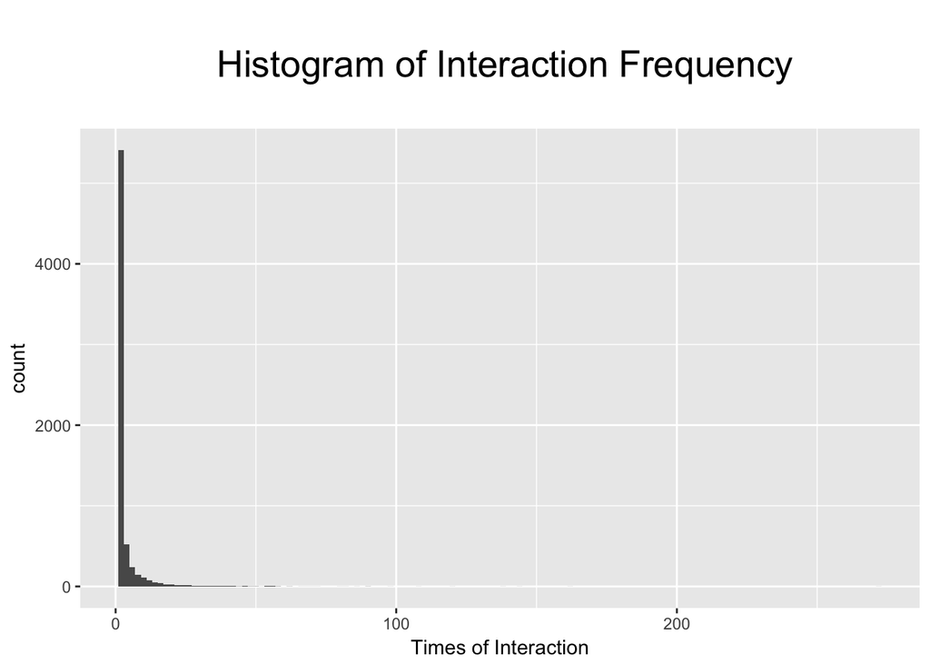

If we define “interaction” as any type of usage, regardless of type1, 2, 3, 4, or 5, then according to this histogram, we know that most customer still stays in the phase of interacting with the app for only one time.

### Breaking Down to Each Customer

To see what each customer is using our app for?

```r
head(UserType)
```

```
##                        UserId Type Number of Usage
## 1    55b1a1bbe674f1ed1b8e8b35    1               1
## 7678 55b1a1bbe674f1ed1b8e8b35    4               1
## 2    55e106457a8ed89034203731    1               4
## 7679 55e106457a8ed89034203731    4               3
## 3    564bd1bc7dd90ec2ff3a28c6    1               8
## 6802 564bd1bc7dd90ec2ff3a28c6    2               3
```

So for customer with id of “55b1a1bbe674f1ed1b8e8b35” got stamp for once and editted his or her profile in store for once; while customer with id of “55e106457a8ed89034203731” got stamp for 4 times and editted his or her profile in store for 3 times.

#### Type4 Usage

```r
length(unique(Wali$userId[Wali$type == 4])) /length(unique(Wali$userId))
```

```
## [1] 0.2092818
```

20.9% of our total customers has at lease editted their profile in store for once, which means that most of our customers editted their profile when they are not in the store or they just never editted their profile.

#### Type5 Usage

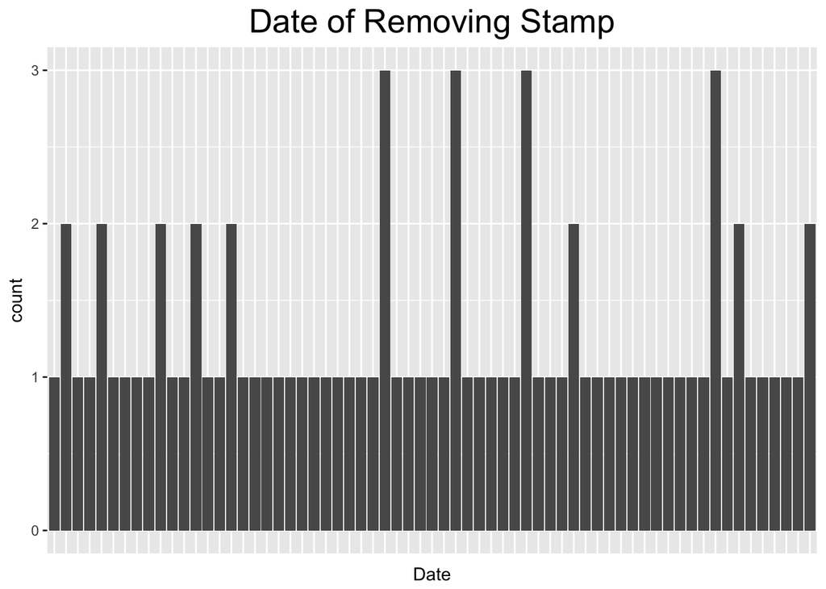

**Question:** How do people remove stamps? Do they do that by themselves? What is the implication of it?

I originally thought that removing stamps means clearning all of the old stamps they have and quitting our app; but it turns out that’s not the case. I wish to understand why people are removing stamps and plotted the date of customers removing stamps. As you can see from the plot, there is no obvious patter, so I did not dig further.